# Лабораторная работа №3

Дискреционное разграничение прав в Linux. Два пользователя

Ежова А. М.

Российский университет дружбы народов, Москва, Россия

Факультет физико-математических и естесвенных наук

12 марта 2024

# Информация

## Докладчик

- Ежова Алиса Михайловна
- студентка НБИбд-02-22
- Российский университет дружбы народов
- https://github.com/AlisaEzhova

[figure not shown]

# Вводная часть

## Актуальность

- Данная работа актуальна для студентов, которые хотят освоить умения по работе с виртуальной машиной.

## Цели и задачи

- Получение практических навыков работы в консоли с атрибутами файлов для групп пользователей.

## Материалы и методы

- Процессор `pandoc` для входного формата Markdown
- Результирующие форматы
  - `pdf`
  - `html`
- Автоматизация процесса создания: `Makefile`

# Создание презентации

## Процессор `pandoc`

- Pandoc: преобразователь текстовых файлов
- Сайт: https://pandoc.org/
- Репозиторий: https://github.com/jgm/pandoc

## Формат `pdf`

- Использование LaTeX
- Пакет для презентации: beamer
- Тема оформления: `metropolis`

## Код для формата `pdf`

```yaml
slide_level: 2
aspectratio: 169
section-titles: true
theme: metropolis
```

## Формат `html`

- Используется фреймворк [reveal.js](https://revealjs.com/)
- Используется [тема](https://revealjs.com/themes/) `beige`

## Код для формата `html`

- Тема задаётся в файле `Makefile`

```
REVEALJS_THEME = beige
```

# Результаты

## Получающиеся форматы

- Полученный `pdf`-файл можно демонстрировать в любой программе просмотра `pdf`
- Полученный `html`-файл содержит в себе все ресурсы: изображения, css, скрипты

## Содержание исследования

1. В установленной операционной системе создала учётную запись пользователя guest (используя учётную запись администратора) и задала пароль для пользователя guest (используя учётную запись администратора):

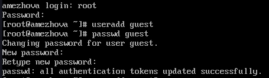

Новая учетная запись

2. Аналогично создала второго пользователя guest2:

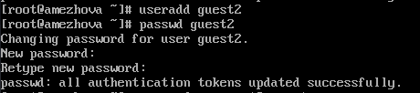

Аналогичный пользватель guest2

3. Добавила пользователя guest2 в группу guest:

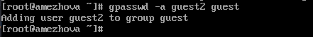

[figure not shown]

4. Осуществила вход в систему от двух пользователей на двух разных консолях: guest на первой консоли и guest2 на второй консоли:

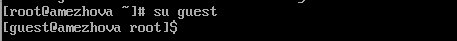

Вход guest1

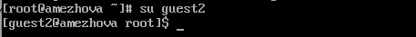

Вход guest2

5. Уточнила имя моего пользователя, его группу, кто входит в неё и к каким группам принадлежит он сам. Определила командами groups guest и groups guest2, в какие группы входят пользователи guest и guest2. Сравнила вывод команды groups с выводом команд id -Gn и id -G.:

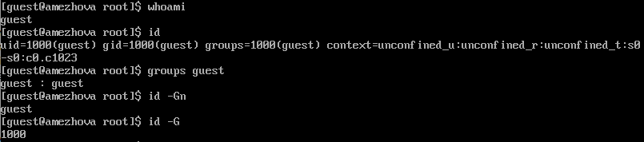

Узнала информацию о guest1

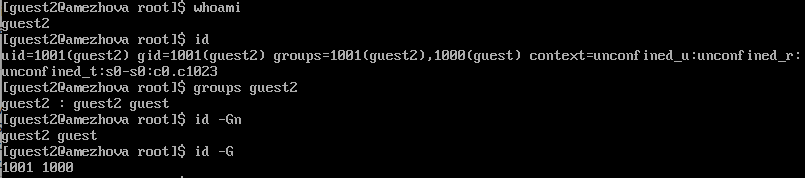

Узнала информацию о guest2

6. Сравнила полученную информацию с содержимым файла /etc/group. Просмотрела файл командой cat /etc/group:

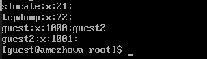

Проосмотр файлов guest1

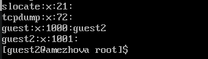

Проосмотр файлов guest2

7. От имени пользователя guest2 выполните регистрацию пользователя guest2 в группе guest командой newgrp guest:

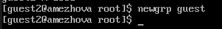

Регистрайия пользователя

8. От имени пользователя guest изменила права директории /home/guest, разрешив все действия для пользователей группы: chmod g+rwx /home/guest От имени пользователя guest снимите с директории /home/guest/dir1 все атрибуты командой chmod 000 dirl:

9. Заполнение и сравнение таблиц:

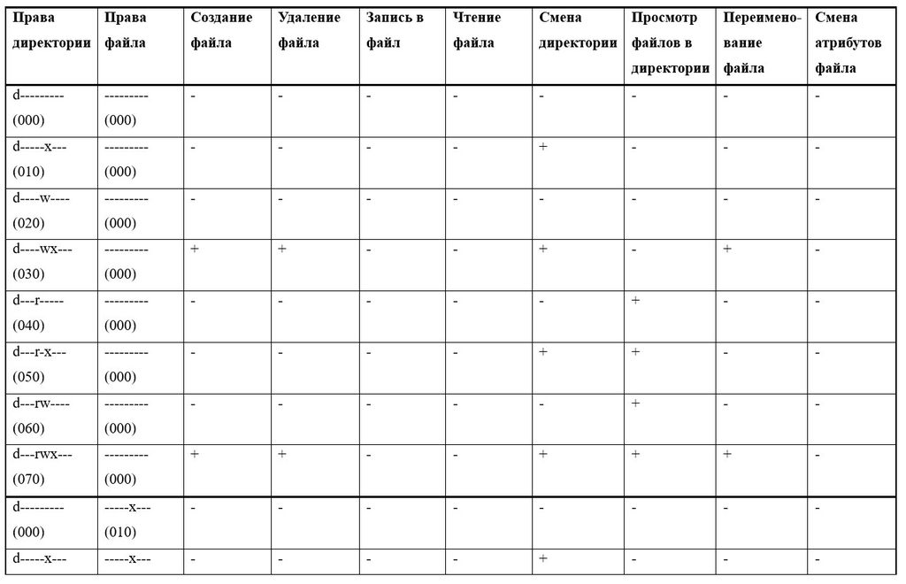

Таблица 1

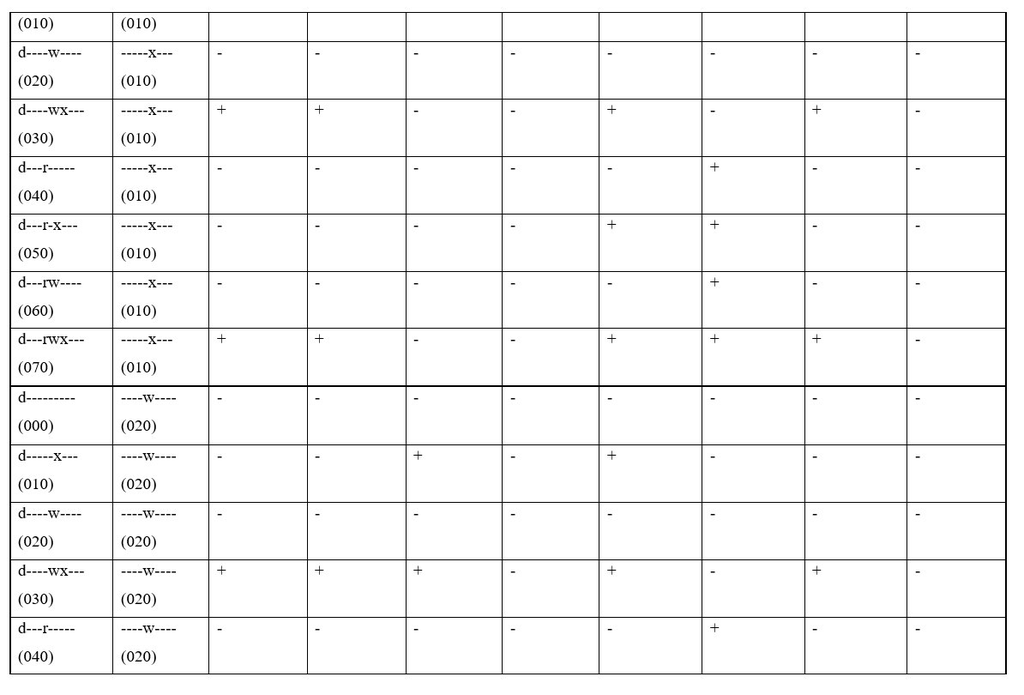

Таблица 1

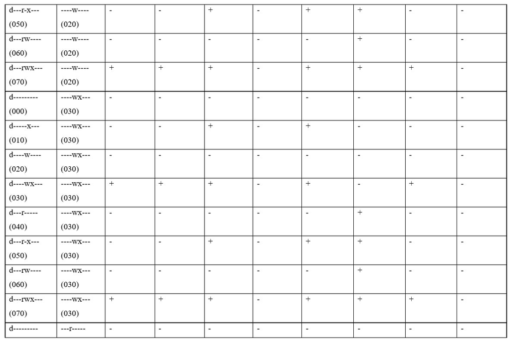

Таблица 1

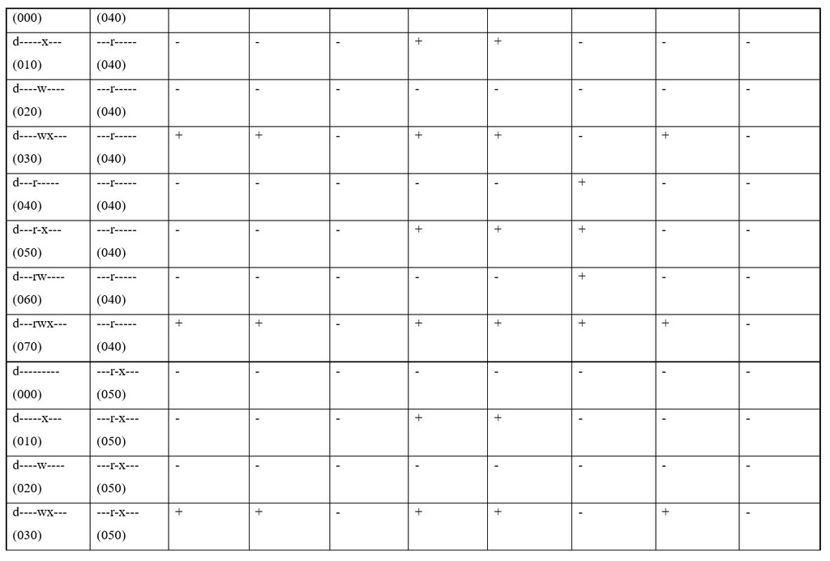

Таблица 1

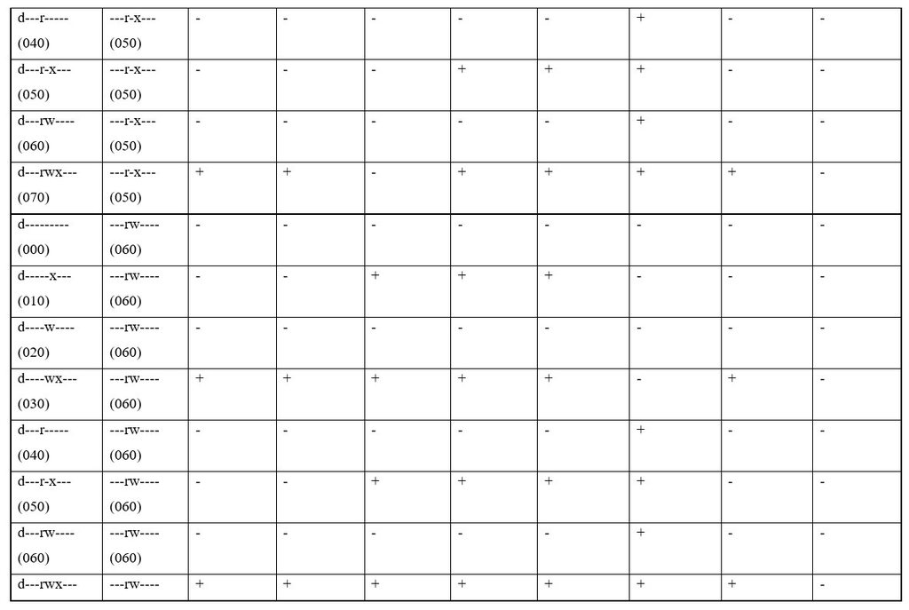

Таблица 1

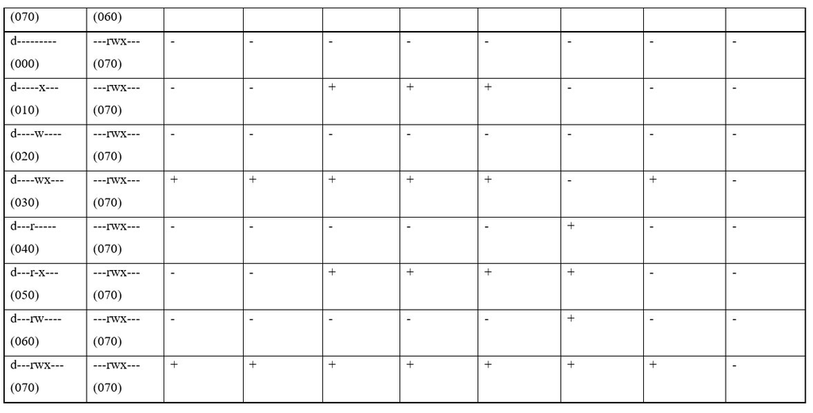

Таблица 1

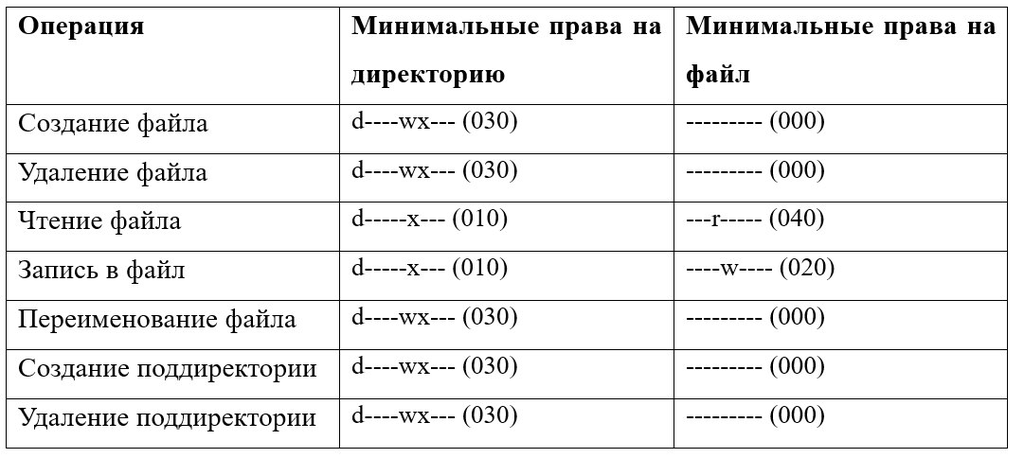

Таблица 2

## Результаты

- Научились работать с виртуальной машиной.

## Итоговый слайд

В процессе выполнения лабораторной работы №3 я получила практические навыки работы в консоли с атрибутами файлов для групп пользователей.